# Untitled

Daniel Kim

4/12/2020

```r
cereal <-read.csv("http://reuningscherer.net/stat660/data/cereal.attitudes.csv")
```

```r
library(vegan)
library(vegan3d)
library(mgcv)
library(MASS)
library(rgl)
```

1. Fit correspondence analysis to your data

```r
#Perform correspondence analysis
cerealcca <- cca(cereal[,2:12])
cerealcca
```

```
## Call: cca(X = cereal[, 2:12])
##
##               Inertia Rank
## Total          0.2697
## Unconstrained  0.2697    7
## Inertia is scaled Chi-square
##
## Eigenvalues for unconstrained axes:
##     CA1     CA2     CA3     CA4     CA5     CA6     CA7
## 0.17191 0.07409 0.01349 0.00919 0.00085 0.00016 0.00005
```

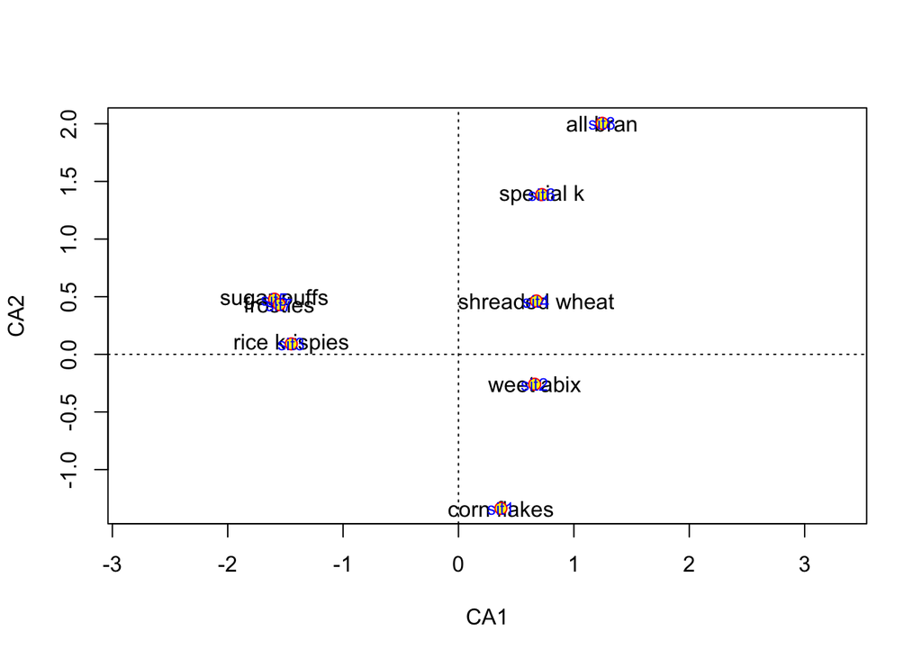

```r
#plot results
plot(cerealcca, type="n" ,xlim=c(-2,2.5))
text(cerealcca, dis="wa",labels=cereal[,1])
points(cerealcca, pch=21, col="red", bg="yellow", cex=1.2)
text(cerealcca, "sites", col="blue", cex=0.8)
```

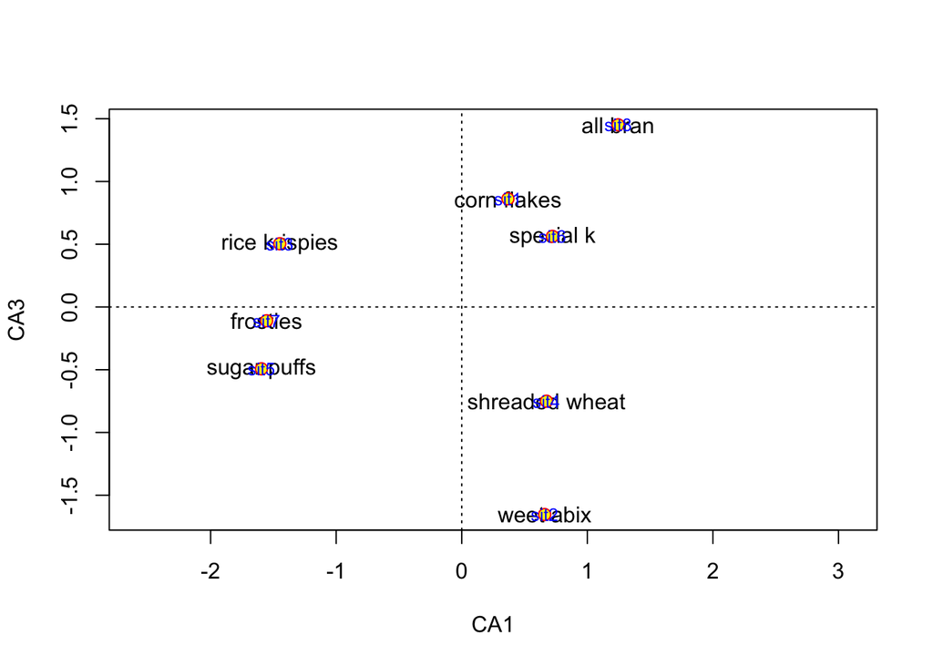

```r
plot(cerealcca, type="n" ,xlim=c(-2,2.5),choices = c(1,3))
text(cerealcca, dis="wa",labels=cereal[,1], choices = c(1,3))
points(cerealcca, pch=21, col="red", bg="yellow", cex=1.2, choices = c(1,3))
text(cerealcca, "sites", col="blue", cex=0.8, choices = c(1,3))
```

3. There seems to be some evidence of “data snaking” in higher dimensional space since the points on the plot. The distribution of the observations suggests there could possibly be data snaking. Looking at the 1st and 3rd component analysis, this pattern reemerges.
4. Cereals like all bran, special k, and Shreaded wheat seem to grouped together which could be because they are healthier cereals. Cereals such as sugar puffs and rece crispies are grouped together which could be because they are sweeter, more kid-friendly cereals.

```r
cereal1 <- cereal[,2:12]

cereal.mds1 <- metaMDS(cereal1, distance="euclidean", k=1)
```

```
## Square root transformation
## Wisconsin double standardization
## *** Solution reached
```

```r
cereal.mds2 <- metaMDS(cereal1, distance="euclidean", k=2)
```

```
## Square root transformation
## Wisconsin double standardization
## *** No convergence -- monoMDS stopping criteria:
##     10: no. of iterations >= maxit
##      5: stress < smin
##      5: stress ratio > sratmax
```

```r
cereal.mds3 <- metaMDS(cereal1, distance="euclidean", k=3)
```

```
## Square root transformation
## Wisconsin double standardization
## *** No convergence -- monoMDS stopping criteria:
##     15: no. of iterations >= maxit
##      3: stress < smin
##      2: stress ratio > sratmax
```

```r
results <- matrix(NA,21,3)
#j is number of dimensions to try
for (j in 1:3){
  for (i in 1:20){
    temp <- cereal1[shuffle(nrow(cereal1)),1]
    for (k in 1:11) { temp <- cbind(temp,cereal1[shuffle(nrow(cereal1)),k]) }
    #store stress
    results[i,j] <- metaMDS(temp, k=j, distance="euclidean")$stress
  }
  results[21,j] <- metaMDS(cereal1[,1:11], k=j, distance="euclidean")$stress
}
```

[output not shown]

[output cut: 98 more lines]

[output not shown]

[output not shown]

[output not shown]

[output not shown]

[output not shown]

[output not shown]

[output not shown]

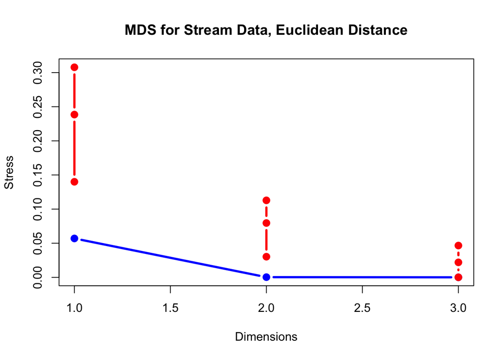

```r
#plot stress results

plot(c(1:3),results[21,],type="b", col="blue", lwd=3,
     ylim=c(0, max(results)), xlab="Dimensions", ylab="Stress", pch=19,
     main="MDS for Stream Data, Euclidean Distance")
mins <- apply(results[1:20,],2,min)
maxs <- apply(results[1:20,],2,max)
meds <- apply(results[1:20,],2,median)

for (i in 1:5){
  points(rep(i,3),c(mins[i], meds[i], maxs[i]),type="b", col="red", lwd=3, pch=19)
}
legend(3.5,(.9*max(results)),c("MDS Solution", "20 Permutations"), lwd=3, col=c("blue","red"))
```

A plot of results suggests that 2 dimensions is a good solution (after that, results are not different than random results)

```r
#two dimensional solution
cereal.mds2 <- metaMDS(cereal[,2:12], k=2, distance="euclidean")
```

```
## Square root transformation
## Wisconsin double standardization
## *** No convergence -- monoMDS stopping criteria:
##     14: no. of iterations >= maxit
##      3: stress < smin
##      3: stress ratio > sratmax
```

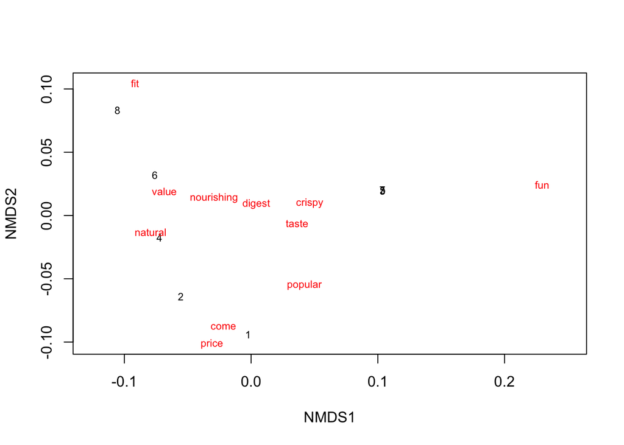

```r
#quick plot
plot(cereal.mds2,type="t")
```

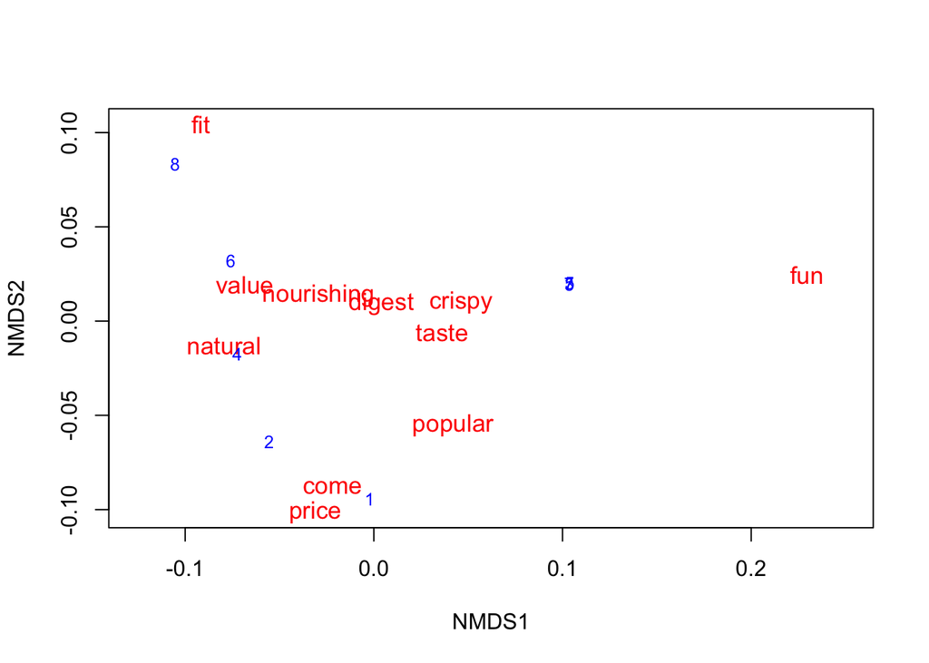

```r
#more refined plot
fig<-ordiplot(cereal.mds2,type="none",cex=1.1)
text(fig,"species",col="red",cex=1.1)
text(fig,"sites",col="blue",cex=0.8)
```

8. There are no other variables to overlay in this dataset. Therefore, we are unable to overlay other variables to interpret our ordination axes